# model

### Note:

Resources:

1. helpful guide: https://slack-files.com/T2HQV035L-F50B85JSX-7d8737aeeb

Data Collection tips:

- 40k samples
- Choose the fastest graphic quality and lowest screen resolution has helped the model to perform better
- I made use of the left and right camera angles also, where I modified the steering angles slightly in these cases. This helped up the number of test cases, and these help cases where the car is off center and teaches it to steer back to the middle.
- two or three laps of center lane driving
- one lap of recovery driving from the sides
- one lap focusing on driving smoothly around curves

Model tips:

- Resize the input image. I was able to size the image down by 2, reducing the number of pixels by 4. This really helped speed up model training and did not seem to impact the accuracy
- Copy the Nvidia pipeline. It works :) And it's not too complex.
- Around 5 epochs seems to be enough training. Any more does not reduce the mse much if at all.

### Import

```python
import csv
import cv2
import numpy as np
import keras
from keras.models import Sequential, load_model
from keras.layers import Cropping2D
from keras.layers.convolutional import Convolution2D
from keras.layers.core import Dense, Activation, Flatten, Lambda
from keras.layers.pooling import MaxPooling2D
import sklearn
from random import shuffle

import matplotlib.pyplot as plt

import copy

%matplotlib inline

%load_ext autoreload
%autoreload 2

print(keras.__version__)
```

```
1.2.1
```

### Select desired folders for training

provid selected folder names for collecting data. Since the data is collected in Windows with the path format: \data\foldernames\IMG\center_2017_10_26_01_32_48_251.jpg' with the traninig done in linux, '\\' has to be replaced by '/'

```python
testnames = ['lap2_3']

samples = []
for testname in testnames:
    with open('data/' + testname + '/driving_log.csv') as csvfile:
        reader = csv.reader(csvfile)
        for line in reader:
            samples.append(line)

print('path example:' + str(line))

from sklearn.model_selection import train_test_split
train_samples, validation_samples = train_test_split(samples, test_size=0.2)
print('Train Sample Size = {}'.format(len(train_samples)))
print('Valid Sample Size = {}'.format(len(validation_samples)))
```

[output not shown]

### Data generator for large dataset

```python
def generator(samples, batch_size=32):
    num_samples = len(samples)
    while 1: # Loop forever so the generator never terminates
        samples_flipped = copy.copy(samples)
        shuffle(samples)
        shuffle(samples_flipped)
        for offset in range(0, num_samples, batch_size):
            batch_samples = samples[offset:offset+batch_size]
            batch_samples_flipped = samples_flipped[offset:offset+batch_size]
            images = []
            angles = []
            correction_left = 0.25
            correction_right = 0.25
            amp_factor = 1.0
            for batch_sample in batch_samples:
                name = 'data/' + batch_sample[0].split('\\')[-3] + '/IMG/' + batch_sample[0].split('\\')[-1]
                center_image = cv2.imread(name)
                center_angle = float(batch_sample[3])
                images.append(center_image)
                angles.append(center_angle)
                name = 'data/' + batch_sample[1].split('\\')[-3] + '/IMG/' + batch_sample[1].split('\\')[-1]
                left_image = cv2.imread(name)
                left_angle = float(batch_sample[3]) + correction_left
                images.append(left_image)
                angles.append(left_angle)
                name = 'data/' + batch_sample[2].split('\\')[-3] + '/IMG/' + batch_sample[2].split('\\')[-1]
                right_image = cv2.imread(name)
                right_angle = float(batch_sample[3]) - correction_right
                images.append(right_image)
                angles.append(right_angle)

            for batch_sample_flipped in batch_samples_flipped:
                name = 'data/' + batch_sample_flipped[0].split('\\')[-3]  + '/IMG/' + batch_sample_flipped[0].split('\\')[-1]
                center_image_flipped = np.fliplr(cv2.imread(name))
                center_angle_flipped = - (float(batch_sample_flipped[3]))
                images.append(center_image_flipped)
                angles.append(center_angle_flipped)
                name = 'data/' + batch_sample_flipped[1].split('\\')[-3]  + '/IMG/' + batch_sample_flipped[1].split('\\')[-1]
                left_image_flipped = np.fliplr(cv2.imread(name))
                left_angle_flipped = - (float(batch_sample_flipped[3]) + correction_left)
                images.append(left_image_flipped)
                angles.append(left_angle_flipped)
                name = 'data/' + batch_sample_flipped[2].split('\\')[-3]  + '/IMG/' + batch_sample_flipped[2].split('\\')[-1]
                right_image_flipped = np.fliplr(cv2.imread(name))
                right_angle_flipped = - (float(batch_sample_flipped[3]) - correction_right)
                images.append(right_image_flipped)
                angles.append(right_angle_flipped)

            # trim image to only see section with road
            X_train = np.array(images)
            y_train = np.array(angles)*amp_factor
            yield sklearn.utils.shuffle(X_train, y_train)

aug_factor = 6
print('Augmented Sample Size = {}'.format(len(samples) * aug_factor))

train_generator = generator(train_samples, batch_size=32)
validation_generator = generator(validation_samples, batch_size=32)
```

```
Augmented Sample Size = 32490
```

### Define Model Structure

```python
# make sure when the code is resued model is deleted
model = Sequential()
del model

# Build Convolutional Neural Network in Keras Here
model = Sequential()
model.add(Lambda(lambda x:x / 255.0 - 0.5,input_shape=(160,320,3)))
model.add(Cropping2D(cropping=((50,25), (0,0))))
model.add(Convolution2D(24, 5, 5, subsample = (2,2), activation='relu'))
model.add(Convolution2D(36, 5, 5, subsample = (2,2), activation='relu'))
model.add(Convolution2D(48, 5, 5, subsample = (2,2), activation='relu'))
model.add(Convolution2D(64, 3, 3, activation='relu'))
model.add(Convolution2D(64, 3, 3, activation='relu'))
model.add(Flatten())
model.add(Dense(100, activation='relu'))
model.add(Dense(50, activation='relu'))
model.add(Dense(10, activation='relu'))
model.add(Dense(1))
```

### Fine-tunning

```python
model = Sequential()
del model
model = load_model('model.h5')
```

```python
for layer in model.layers:
    layer.trainable = False
model.layers[-4].trainable = True
model.layers[-3].trainable = True
model.layers[-2].trainable = True
model.layers[-1].trainable = True
```

```python
#lr = 5e-4
adam = keras.optimizers.Adam(lr=5e-4, beta_1=0.9, beta_2=0.999, epsilon=1e-08, decay=0.1)
model.compile(loss = 'mse',optimizer = adam)
model.fit_generator(train_generator, samples_per_epoch= aug_factor*len(train_samples), validation_data=validation_generator,\
                    nb_val_samples=aug_factor*len(validation_samples), nb_epoch=5)
```

```
<keras.callbacks.History at 0x7f31445f29e8>
```

```python
model.save('model_new.h5')
del model
```

### Pick some image samples and validate the model

```python
import os
list_imgs = os.listdir("data/real1/")
```

```python
images = []
steers = []
paths = []
testname = 'real1'

def output_samples(samples):
    steer_neg = 0.0
    steer_pos = 0.0
    X_sample = np.zeros([3,160,320,3],dtype = np.uint8)
    y_sample = np.zeros(3)
    for line in samples:
        source_path = line[0]
        current_path = 'data/' + source_path.split('\\')[-3]+ '/IMG/' + source_path.split('\\')[-1]
        steer = float(line[3])
        if steer > steer_pos and steer < 0.9:
            X_sample[2,:,:,:] = np.array(cv2.imread(current_path))
            y_sample[2] = steer
            steer_pos = steer
        if steer < steer_neg and steer > -0.9:
            X_sample[0,:,:,:] = np.array(cv2.imread(current_path))
            y_sample[0] = steer
            steer_neg = steer
        if steer == 0:
            X_sample[1,:,:,:] = np.array(cv2.imread(current_path))
            y_sample[1] = steer
    return X_sample, y_sample

def output_samples_pick(idxs, samples):
    X_sample = np.zeros([3,160,320,3],dtype = np.uint8)
    y_sample = np.zeros(3)
    i = 0
    for idx in idxs:
        line = samples[idx-1]
        source_path = line[0]
        filename = source_path.split('\\')[-1]
        current_path = 'data/' + testname + '/IMG/' + filename
        steer = float(line[3])
        X_sample[i,:,:,:] = np.array(cv2.imread(current_path))
        y_sample[i] = steer
        i += 1
    return X_sample, y_sample

def real_pick(idxs, list_imgs):
    X_sample = np.zeros([3,160,320,3],dtype = np.uint8)
    y_sample = np.zeros(3)
    i = 0
    for idx in idxs:
        filename = list_imgs[idx]
        current_path = 'data/real1/'+filename
        X_sample[i,:,:,:] = np.array(cv2.imread(current_path))
        i += 1
    return X_sample
```

```
<function matplotlib.pyplot.show>
```

[figure not shown]

```python
idxs = [0, 1, 2]
X_sample= real_pick(idxs,list_imgs)
model = load_model('model.h5')
ans = model.predict(X_sample, batch_size=1)
plt.subplot(131)
plt.imshow(cv2.cvtColor(X_sample[0], cv2.COLOR_BGR2RGB))
plt.title('predited steering angle =' + str(ans[0]))
plt.subplot(132)
plt.imshow(cv2.cvtColor(X_sample[1], cv2.COLOR_BGR2RGB))
plt.title('predited steering angle = ' + str(ans[1]))
plt.subplot(133)
plt.imshow(cv2.cvtColor(X_sample[2], cv2.COLOR_BGR2RGB))
plt.title('predited steering angle = ' + str(ans[2]))
plt.gcf().set_size_inches(16,4)
plt.show
```

### Image Utility

[figure not shown]

```python
plt.imshow(cv2.cvtColor(X_sample[0], cv2.COLOR_BGR2RGB))
```

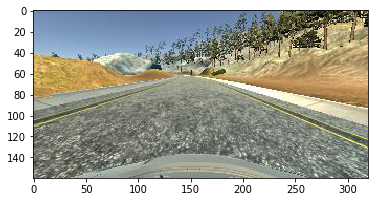

```python
current_path = 'data/test2/IMG/center_2017_10_15_12_20_41_874.jpg'
image = cv2.imread(current_path)
plt.imshow(cv2.cvtColor(np.array(image), cv2.COLOR_BGR2RGB))
```

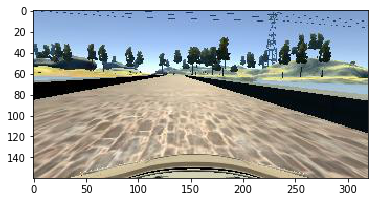

```python
current_path = 'data/test3/IMG/center_2017_10_16_12_17_51_803.jpg'
image = cv2.imread(current_path)
plt.imshow(cv2.cvtColor(np.array(image), cv2.COLOR_BGR2RGB))
```

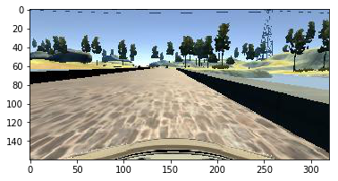

```python
current_path = 'data/test3/IMG/center_2017_10_16_12_17_53_707.jpg'
image = cv2.imread(current_path)
plt.imshow(cv2.cvtColor(np.array(image), cv2.COLOR_BGR2RGB))
```

[figure not shown]

```python
current_path = 'data/test3/IMG/center_2017_10_16_12_17_54_862.jpg'
image = cv2.imread(current_path)
plt.imshow(cv2.cvtColor(np.array(image), cv2.COLOR_BGR2RGB))
```

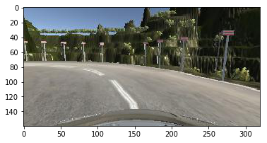

```python
current_path = 'data/lap2_2/IMG/center_2017_10_23_22_29_27_952.jpg'
image = cv2.imread(current_path)
plt.imshow(cv2.cvtColor(np.array(image), cv2.COLOR_BGR2RGB))
```

[figure not shown]

```python
current_path = 'data/lap2_2/IMG/center_2017_10_23_22_29_27_952.jpg'
image = np.fliplr(cv2.imread(current_path))
plt.imshow(cv2.cvtColor(np.array(image), cv2.COLOR_BGR2RGB))
```

```
<function matplotlib.pyplot.show>
```

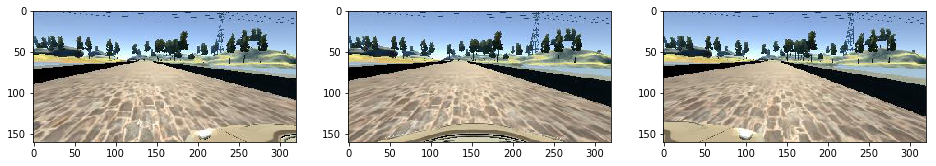

```python
plt.subplot(131)
image = cv2.imread('data/test3/IMG/left_2017_10_16_12_17_51_803.jpg')
plt.imshow(cv2.cvtColor(image, cv2.COLOR_BGR2RGB))
plt.subplot(132)
image = cv2.imread('data/test3/IMG/center_2017_10_16_12_17_51_803.jpg')
plt.imshow(cv2.cvtColor(image, cv2.COLOR_BGR2RGB))
plt.subplot(133)
image = cv2.imread('data/test3/IMG/right_2017_10_16_12_17_51_803.jpg')
plt.imshow(cv2.cvtColor(image, cv2.COLOR_BGR2RGB))
plt.gcf().set_size_inches(16,4)
plt.show
```